# Investigate Ford Bike Sharing Data of June 2019

## Preliminary Wrangling

Ford GoBike is a regional public bicycle sharing system in the San Francisco Bay Area, California. Starting in August 2013 as Bay Area Bike Share, the Ford GoBike system currently has over 2,600 bicycles in 262 stations across San Francisco, East Bay and San Jose. Since 2017 the sharing service has partnered with Ford Motor Company and is now called Ford Go Bike.

Ford GoBike offers bikes that are locked into a network of docking stations across the city. The customer can unlock the bikes and lock them somewhere else. This make it perfect for one-way trips. Therer are plentz of ways people use the bikes. To get to appointments or social engagements or to get to the train. This mobility concepts is very convenient and affordable way for people of all ages.

The bikes are available for use 24 hours/day, 7 days/week, 365 days/year and riders have access to all bikes in the network when they become a member or purchase a pass.

```python
import numpy as np
import pandas as pd
import matplotlib.pyplot as plt
%matplotlib inline
import seaborn as sb
from jupyterthemes import jtplot
# chesterish', 'onedork', 'monokai', 'solarizedl', 'solarizedd'.
jtplot.style(theme='solarizedd')
import datetime
```

> Load in your dataset and describe its properties through the questions below. Try and motivate your exploration goals through this section.

```python
# loading the data records for the may session of 2019
df = pd.read_csv('data/201906-baywheels-tripdata.csv')
df.head()
```

|  | duration_sec | start_time | end_time | start_station_id | start_station_name | start_station_latitude | start_station_longitude | end_station_id | end_station_name | end_station_latitude | end_station_longitude | bike_id | user_type | bike_share_for_all_trip | rental_access_method |
| --- | --- | --- | --- | --- | --- | --- | --- | --- | --- | --- | --- | --- | --- | --- | --- |
| 0 | 81695 | 2019-06-30 18:16:09.7730 | 2019-07-01 16:57:45.5920 | 109.0 | 17th St at Valencia St | 37.763316 | -122.421904 | 56.0 | Koshland Park | 37.773414 | -122.427317 | 1502 | Subscriber | No | NaN |
| 1 | 74260 | 2019-06-30 18:09:55.8300 | 2019-07-01 14:47:36.6810 | 50.0 | 2nd St at Townsend St | 37.780526 | -122.390288 | 101.0 | 15th St at Potrero Ave | 37.767079 | -122.407359 | 2526 | Customer | No | NaN |
| 2 | 59603 | 2019-06-30 15:40:31.0380 | 2019-07-01 08:13:54.3490 | 23.0 | The Embarcadero at Steuart St | 37.791464 | -122.391034 | 30.0 | San Francisco Caltrain (Townsend St at 4th St) | 37.776598 | -122.395282 | 2427 | Subscriber | No | NaN |
| 3 | 67932 | 2019-06-30 12:49:47.7810 | 2019-07-01 07:42:00.5430 | 169.0 | Bushrod Park | 37.846516 | -122.265304 | 248.0 | Telegraph Ave at Ashby Ave | 37.855956 | -122.259795 | 1261 | Customer | No | NaN |
| 4 | 48894 | 2019-06-30 17:21:00.0550 | 2019-07-01 06:55:54.9960 | 15.0 | San Francisco Ferry Building (Harry Bridges Pl... | 37.795392 | -122.394203 | 30.0 | San Francisco Caltrain (Townsend St at 4th St) | 37.776598 | -122.395282 | 1070 | Customer | No | NaN |

```python
# Sampling for required cleaning needed
df.sample(10)
```

|  | duration_sec | start_time | end_time | start_station_id | start_station_name | start_station_latitude | start_station_longitude | end_station_id | end_station_name | end_station_latitude | end_station_longitude | bike_id | user_type | bike_share_for_all_trip | rental_access_method |
| --- | --- | --- | --- | --- | --- | --- | --- | --- | --- | --- | --- | --- | --- | --- | --- |
| 145012 | 262 | 2019-06-07 16:50:32.0750 | 2019-06-07 16:54:55.0070 | 5.0 | Powell St BART Station (Market St at 5th St) | 37.783899 | -122.408445 | 19.0 | Post St at Kearny St | 37.788975 | -122.403452 | 1116 | Subscriber | No | NaN |
| 142170 | 217 | 2019-06-07 23:39:07.6250 | 2019-06-07 23:42:45.4740 | 258.0 | University Ave at Oxford St | 37.872355 | -122.266447 | 251.0 | California St at University Ave | 37.870555 | -122.279720 | 2141 | Subscriber | No | NaN |
| 45497 | 3256 | 2019-06-23 18:59:14.0490 | 2019-06-23 19:53:30.1020 | 24.0 | Spear St at Folsom St | 37.789677 | -122.390428 | 23.0 | The Embarcadero at Steuart St | 37.791464 | -122.391034 | 395 | Customer | No | NaN |
| 84134 | 2078 | 2019-06-17 18:47:04.6690 | 2019-06-17 19:21:43.3620 | 296.0 | 5th St at Virginia St | 37.325998 | -121.877120 | 287.0 | Almaden Blvd at Balbach St | 37.326730 | -121.889273 | 352 | Customer | No | NaN |
| 112089 | 433 | 2019-06-12 18:31:35.9750 | 2019-06-12 18:38:49.6520 | 119.0 | 18th St at Noe St | 37.761047 | -122.432642 | 86.0 | Market St at Dolores St | 37.769305 | -122.426826 | 3540 | Subscriber | No | NaN |
| 136958 | 195 | 2019-06-09 10:00:15.5690 | 2019-06-09 10:03:30.6630 | 115.0 | Jackson Playground | 37.765026 | -122.398773 | 104.0 | 4th St at 16th St | 37.767045 | -122.390833 | 2324 | Subscriber | No | NaN |
| 34322 | 510 | 2019-06-25 13:22:57.3160 | 2019-06-25 13:31:27.3310 | 23.0 | The Embarcadero at Steuart St | 37.791464 | -122.391034 | 67.0 | San Francisco Caltrain Station 2 (Townsend St... | 37.776639 | -122.395526 | 2045 | Subscriber | No | NaN |
| 73149 | 1384 | 2019-06-19 09:06:43.6410 | 2019-06-19 09:29:48.2390 | 5.0 | Powell St BART Station (Market St at 5th St) | 37.783899 | -122.408445 | 81.0 | Berry St at 4th St | 37.775880 | -122.393170 | 3375 | Subscriber | No | NaN |
| 20870 | 952 | 2019-06-27 08:41:01.8700 | 2019-06-27 08:56:54.7870 | 25.0 | Howard St at 2nd St | 37.786928 | -122.398113 | 115.0 | Jackson Playground | 37.765026 | -122.398773 | 1325 | Customer | No | NaN |
| 88689 | 613 | 2019-06-17 08:44:32.6400 | 2019-06-17 08:54:46.1340 | 200.0 | 2nd Ave at E 18th St | 37.800214 | -122.253810 | 163.0 | Lake Merritt BART Station | 37.797320 | -122.265320 | 268 | Subscriber | No | NaN |

```python
df.info()
```

```
<class 'pandas.core.frame.DataFrame'>
RangeIndex: 191772 entries, 0 to 191771
Data columns (total 15 columns):
 #   Column                   Non-Null Count   Dtype
---  ------                   --------------   -----
 0   duration_sec             191772 non-null  int64
 1   start_time               191772 non-null  object
 2   end_time                 191772 non-null  object
 3   start_station_id         189612 non-null  float64
 4   start_station_name       189612 non-null  object
 5   start_station_latitude   191772 non-null  float64
 6   start_station_longitude  191772 non-null  float64
 7   end_station_id           189510 non-null  float64
 8   end_station_name         189510 non-null  object
 9   end_station_latitude     191772 non-null  float64
 10  end_station_longitude    191772 non-null  float64
 11  bike_id                  191772 non-null  int64
 12  user_type                191772 non-null  object
 13  bike_share_for_all_trip  187879 non-null  object
 14  rental_access_method     3893 non-null    object
dtypes: float64(6), int64(2), object(7)
memory usage: 21.9+ MB
```

```python
df.describe()
```

|  | duration_sec | start_station_id | start_station_latitude | start_station_longitude | end_station_id | end_station_latitude | end_station_longitude | bike_id |
| --- | --- | --- | --- | --- | --- | --- | --- | --- |
| count | 191772.000000 | 189612.000000 | 191772.000000 | 191772.000000 | 189510.000000 | 191772.000000 | 191772.000000 | 191772.000000 |
| mean | 841.814608 | 139.909505 | 37.762560 | -122.348320 | 137.484645 | 37.762698 | -122.347756 | 10641.887439 |
| std | 1936.720801 | 118.054453 | 0.112639 | 0.169730 | 117.447948 | 0.112538 | 0.169336 | 68253.875020 |
| min | 60.000000 | 3.000000 | 37.290060 | -122.453704 | 3.000000 | 37.255975 | -122.453704 | 12.000000 |
| 25% | 375.000000 | 44.000000 | 37.769305 | -122.411738 | 43.000000 | 37.770030 | -122.411306 | 1028.000000 |
| 50% | 596.000000 | 98.000000 | 37.780526 | -122.398113 | 96.000000 | 37.780526 | -122.397086 | 1937.500000 |
| 75% | 925.000000 | 226.000000 | 37.795392 | -122.293400 | 220.000000 | 37.795392 | -122.293528 | 2975.000000 |
| max | 85952.000000 | 443.000000 | 45.510000 | -73.570000 | 443.000000 | 45.510000 | -73.570000 | 985110.000000 |

```python
df.isnull().sum()
```

```
duration_sec                    0
start_time                      0
end_time                        0
start_station_id             2160
start_station_name           2160
start_station_latitude          0
start_station_longitude         0
end_station_id               2262
end_station_name             2262
end_station_latitude            0
end_station_longitude           0
bike_id                         0
user_type                       0
bike_share_for_all_trip      3893
rental_access_method       187879
dtype: int64
```

```python
# check for duplicates -
df.duplicated().sum()
# no duplicate here
```

```
0
```

### Cleaning

We have a tidy dataset but there are some other issues we want to fix beforehand

Missing time stamp format

- Start/end times

Missing values

- start_station_id
- start_station_name
- end_station_id
- end_station_name

Make columns object format

- start_station_id
- end_station_id
- bike_id

```python
## save the original data set into a new clean dataset
df_cleaned = df.copy()
```

Define: Missing Values - Since the missing values proportion is minor to the overall entries I keep it easy and drop the missing values.

```python
#code
df_cleaned = df_cleaned[df_cleaned['start_station_id'].isnull() == False]
df_cleaned = df_cleaned[df_cleaned['end_station_id'].isnull() == False]
#test
df_cleaned.isnull().sum()
# looks good
```

```
duration_sec                    0
start_time                      0
end_time                        0
start_station_id                0
start_station_name              0
start_station_latitude          0
start_station_longitude         0
end_station_id                  0
end_station_name                0
end_station_latitude            0
end_station_longitude           0
bike_id                         0
user_type                       0
bike_share_for_all_trip      1190
rental_access_method       187879
dtype: int64
```

Define: Data Format - Converting some of the columns to the correct data type

- times to the timestamp format
- Bike ID, start station ID, and end station ID to object format
- User type and bike share for all to category format

```python
#code for time stamp formatting
df_cleaned.start_time = pd.to_datetime(df_cleaned.start_time)
df_cleaned.end_time = pd.to_datetime(df_cleaned.end_time)
```

```python
# Changing the bike_id, start_station_id, and end_station_id to object
df_cleaned.start_station_id = df_cleaned.start_station_id.astype(str)
df_cleaned.end_station_id = df_cleaned.end_station_id.astype(str)
df_cleaned.bike_id = df_cleaned.bike_id.astype(str)
```

```python
# Change user_type and bike_share_for_all_trip to category format
df_cleaned.user_type = df_cleaned.user_type.astype('category')
df_cleaned.bike_share_for_all_trip = df_cleaned.bike_share_for_all_trip.astype('category')
```

```python
#Test
df_cleaned.info(null_counts = True)
# looks good now
```

```
<class 'pandas.core.frame.DataFrame'>
Int64Index: 189069 entries, 0 to 191604
Data columns (total 15 columns):
 #   Column                   Non-Null Count   Dtype
---  ------                   --------------   -----
 0   duration_sec             189069 non-null  int64
 1   start_time               189069 non-null  datetime64[ns]
 2   end_time                 189069 non-null  datetime64[ns]
 3   start_station_id         189069 non-null  object
 4   start_station_name       189069 non-null  object
 5   start_station_latitude   189069 non-null  float64
 6   start_station_longitude  189069 non-null  float64
 7   end_station_id           189069 non-null  object
 8   end_station_name         189069 non-null  object
 9   end_station_latitude     189069 non-null  float64
 10  end_station_longitude    189069 non-null  float64
 11  bike_id                  189069 non-null  object
 12  user_type                189069 non-null  category
 13  bike_share_for_all_trip  187879 non-null  category
 14  rental_access_method     1190 non-null    object
dtypes: category(2), datetime64[ns](2), float64(4), int64(1), object(6)
memory usage: 20.6+ MB
```

```python
df_cleaned.head()
```

|  | duration_sec | start_time | end_time | start_station_id | start_station_name | start_station_latitude | start_station_longitude | end_station_id | end_station_name | end_station_latitude | end_station_longitude | bike_id | user_type | bike_share_for_all_trip | rental_access_method |
| --- | --- | --- | --- | --- | --- | --- | --- | --- | --- | --- | --- | --- | --- | --- | --- |
| 0 | 81695 | 2019-06-30 18:16:09.773 | 2019-07-01 16:57:45.592 | 109.0 | 17th St at Valencia St | 37.763316 | -122.421904 | 56.0 | Koshland Park | 37.773414 | -122.427317 | 1502 | Subscriber | No | NaN |
| 1 | 74260 | 2019-06-30 18:09:55.830 | 2019-07-01 14:47:36.681 | 50.0 | 2nd St at Townsend St | 37.780526 | -122.390288 | 101.0 | 15th St at Potrero Ave | 37.767079 | -122.407359 | 2526 | Customer | No | NaN |
| 2 | 59603 | 2019-06-30 15:40:31.038 | 2019-07-01 08:13:54.349 | 23.0 | The Embarcadero at Steuart St | 37.791464 | -122.391034 | 30.0 | San Francisco Caltrain (Townsend St at 4th St) | 37.776598 | -122.395282 | 2427 | Subscriber | No | NaN |
| 3 | 67932 | 2019-06-30 12:49:47.781 | 2019-07-01 07:42:00.543 | 169.0 | Bushrod Park | 37.846516 | -122.265304 | 248.0 | Telegraph Ave at Ashby Ave | 37.855956 | -122.259795 | 1261 | Customer | No | NaN |
| 4 | 48894 | 2019-06-30 17:21:00.055 | 2019-07-01 06:55:54.996 | 15.0 | San Francisco Ferry Building (Harry Bridges Pl... | 37.795392 | -122.394203 | 30.0 | San Francisco Caltrain (Townsend St at 4th St) | 37.776598 | -122.395282 | 1070 | Customer | No | NaN |

```python
# Create some more columns for making the visuals easier later on
# Add columns for start month, day, and hours
# Add column for the duration in minutes
# These columns and the units will provide a better base for a fast understanding
```

```python
# days
df_cleaned['start_time_weekday'] = df_cleaned['start_time'].dt.strftime('%a')
# hours
df_cleaned['start_time_hour'] = df_cleaned['start_time'].dt.hour
df_cleaned['end_time_hour'] = df_cleaned['end_time'].dt.hour

# This would be much more valuable in case I would have a bigger dataset of a yearly duration - Anyway I want to intrduce this code here in case I want to extenc the time frame of the data set later
# Start time month - 12 month calender
df_cleaned['start_time_month'] = df_cleaned['start_time'].dt.strftime('%B')
# Start time month numeric
df_cleaned['start_time_month_num'] = df_cleaned['start_time'].dt.month.astype(int)
```

```python
# Duration in seconds to duration in minutes
df_cleaned['duration_min'] = df_cleaned['duration_sec']/60
df_cleaned['duration_min'] = df_cleaned['duration_min'].astype(int)
```

```python
# test
df_cleaned.sample(5)
```

|  | duration_sec | start_time | end_time | start_station_id | start_station_name | start_station_latitude | start_station_longitude | end_station_id | end_station_name | end_station_latitude | ... | bike_id | user_type | bike_share_for_all_trip | rental_access_method | start_time_weekday | start_time_hour | end_time_hour | start_time_month | start_time_month_num | duration_min |
| --- | --- | --- | --- | --- | --- | --- | --- | --- | --- | --- | --- | --- | --- | --- | --- | --- | --- | --- | --- | --- | --- |
| 57721 | 804 | 2019-06-21 10:47:02.861 | 2019-06-21 11:00:27.504 | 44.0 | Civic Center/UN Plaza BART Station (Market St ... | 37.781074 | -122.411738 | 9.0 | Broadway at Battery St | 37.798572 | ... | 3176 | Subscriber | No | NaN | Fri | 10 | 11 | June | 6 | 13 |
| 130576 | 1342 | 2019-06-10 10:42:14.246 | 2019-06-10 11:04:36.387 | 76.0 | McCoppin St at Valencia St | 37.771662 | -122.422423 | 23.0 | The Embarcadero at Steuart St | 37.791464 | ... | 3507 | Subscriber | No | NaN | Mon | 10 | 11 | June | 6 | 22 |
| 11682 | 1303 | 2019-06-28 14:37:28.640 | 2019-06-28 14:59:11.789 | 245.0 | Downtown Berkeley BART | 37.870139 | -122.268422 | 245.0 | Downtown Berkeley BART | 37.870139 | ... | 1637 | Customer | No | NaN | Fri | 14 | 14 | June | 6 | 21 |
| 133675 | 565 | 2019-06-09 20:28:44.325 | 2019-06-09 20:38:09.756 | 122.0 | 19th St at Mission St | 37.760299 | -122.418892 | 139.0 | Garfield Square (25th St at Harrison St) | 37.751017 | ... | 597 | Subscriber | No | NaN | Sun | 20 | 20 | June | 6 | 9 |
| 3150 | 416 | 2019-06-30 11:02:09.416 | 2019-06-30 11:09:06.125 | 89.0 | Division St at Potrero Ave | 37.769218 | -122.407646 | 126.0 | Esprit Park | 37.761634 | ... | 321 | Subscriber | No | NaN | Sun | 11 | 11 | June | 6 | 6 |

5 rows × 21 columns

```python
df_cleaned.info(null_counts = True)
```

```
<class 'pandas.core.frame.DataFrame'>
Int64Index: 189069 entries, 0 to 191604
Data columns (total 21 columns):
 #   Column                   Non-Null Count   Dtype
---  ------                   --------------   -----
 0   duration_sec             189069 non-null  int64
 1   start_time               189069 non-null  datetime64[ns]
 2   end_time                 189069 non-null  datetime64[ns]
 3   start_station_id         189069 non-null  object
 4   start_station_name       189069 non-null  object
 5   start_station_latitude   189069 non-null  float64
 6   start_station_longitude  189069 non-null  float64
 7   end_station_id           189069 non-null  object
 8   end_station_name         189069 non-null  object
 9   end_station_latitude     189069 non-null  float64
 10  end_station_longitude    189069 non-null  float64
 11  bike_id                  189069 non-null  object
 12  user_type                189069 non-null  category
 13  bike_share_for_all_trip  187879 non-null  category
 14  rental_access_method     1190 non-null    object
 15  start_time_weekday       189069 non-null  object
 16  start_time_hour          189069 non-null  int64
 17  end_time_hour            189069 non-null  int64
 18  start_time_month         189069 non-null  object
 19  start_time_month_num     189069 non-null  int32
 20  duration_min             189069 non-null  int32
dtypes: category(2), datetime64[ns](2), float64(4), int32(2), int64(3), object(8)
memory usage: 27.8+ MB
```

```python
df_cleaned.to_csv('data/201906_clean_baywheels_tripdata.csv', index = False)
```

### What is the structure of your dataset?

We investigating data from Summer of June 2019 During this time the data shows approximately 189069 bike rides in the San Francisco Bay area of California

### The column header descriptions are as follows:

- Trip Duration (seconds)
- Start Time and Date
- End Time and Date
- Start Station ID
- Start Station Name
- Start Station Latitude
- Start Station Longitude
- End Station ID
- End Station Name
- End Station Latitude
- End Station Longitude
- Bike ID
- User Type (Subscriber or Customer – “Subscriber” = Member or “Customer” = Casual)

##### Following columns are added manually

- Start Time Month
- Start Time Month Number
- Start Time Day of the Week
- Start Time Hour
- Duration in minutes

### What is/are the main feature(s) of interest in your dataset?

#### The main features:

- data related to the start and end of a ride ** It's good for demand analysis - high or low demand.
- User type data and timing data - whether they are a paying member or a casual user. Which day of the week bikes should be most available. This information can be used to make business decisions
- What days are the most frequent ones for what user type

### What features in the dataset do you think will help support your investigation into your feature(s) of interest?

- user_type
- usgae duration [min]
- start_time_weekday
- start_time_hour
- bike_ID

## Univariate Plots

```python
# set the color palette to one color - blue
no_color = sb.color_palette()[0]
```

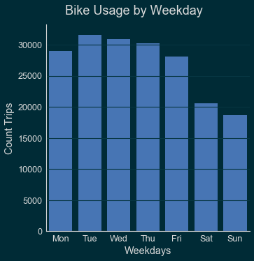

```python
# Chaeck the usage per week day using the "start_time_weekday" feature
# Weekday usage of the Ford Go bike system
# create some helper data
weekdays = ['Mon', 'Tue', 'Wed', 'Thu', 'Fri', 'Sat', 'Sun']
# actual plot
ax = sb.catplot(data=df_cleaned, x='start_time_weekday', kind='count', color = no_color, order = weekdays)
# polish the plot a bit
ax.fig.suptitle('Bike Usage by Weekday', y=1.04, fontsize=18, fontweight='normal');
ax.set_axis_labels('Weekdays', 'Count Trips')
ax.set_xticklabels(rotation=0);
```

*Observation* Tuesdays and Wednesdays seem to be the most popular days for using the bike sharing system in June 2019. Nevertheless Mondays, Thursdays, and Fridays don't differ much. We can see a significant drop on Saturdays and Sundays by more then 10000 rides in compare to the Tuesday.This somehow gives an indicator that the Fors bike sharing is used primarily for commuting purposes during working days and less for pleasure on free days like the weekend.

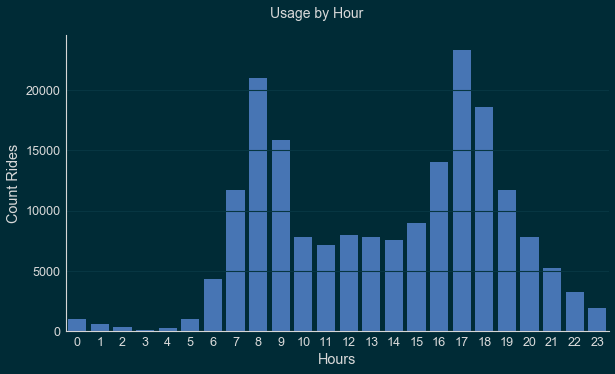

```python
#PLot the hourly usage during the day
ax = sb.catplot(data = df_cleaned, x='start_time_hour', kind='count', color = no_color, aspect = 1.7)

ax.set_axis_labels('Hours', 'Count Rides')

ax.fig.suptitle('Usage by Hour', y=1.04, fontsize=14, fontweight='normal');
```

*Observiation:* This diagram shows a high usage fot the commute hours of most jobs. These times are 6-9am and 4-6pm. This gives another indicator for the hunch that the bike share system is primarily used for commuting. It is almost not used at all between 0-5am.

```python
# look atthe distribution for designing the bin size
df_cleaned.duration_min.describe(percentiles = [.95])
df_cleaned.duration_min.describe()

# Choose Bin size: Overview
# 1. Bins should be all the same size. ...
# 2. Bins should include all of the data, even outliers. ...
# 3. Boundaries for bins should land at whole numbers whenever possible (this makes the chart easier to read).
# 4. Choose between 5 and 20 bins.

# Best explained witht the Freedman Diaconis Rule described here

#bw <- 2 * IQR(x) / length(x)^(1/3)
# bw = 15 - 9 / 189000^0.3 = 0.47  --> 0.5
```

```
count    189069.000000
mean         13.542929
std          32.451795
min           1.000000
25%           6.000000
50%           9.000000
75%          15.000000
max        1432.000000
Name: duration_min, dtype: float64
```

```python
len(df_cleaned.duration_min)
```

```
189069
```

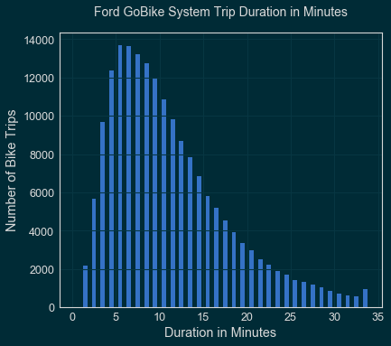

```python
# desig the ticks and bins according to the stats describe() output
bin_edges = np.arange(0, 35, 1)
ticks = [0, 5, 10, 15, 20, 25, 30,  35]
labels = ['{}'.format(items) for items in ticks]

plt.hist(data = df_cleaned, x = 'duration_min', bins = bin_edges, rwidth = 0.5);
#sb.distplot(df_cleaned['duration_min'], bins = bin_edges, kde = False, hist_kws = {'alpha' : 1});

plt.title("Ford GoBike System Trip Duration in Minutes", y=1.04, fontsize=14, fontweight='normal')
plt.xlabel('Duration in Minutes')
plt.xticks(ticks, labels)
plt.ylabel('Number of Bike Trips');
```

## Bivariate Exploration

In this section we investigate relationships between pairs of variables of our data.

```python
# prepare plot data for the customer amount and subscriber amount
#Overall amount of customer
customer = df_cleaned.query('user_type == "Customer"')['bike_id'].count()
#Overall amount of subscriber
subscriber = df_cleaned.query('user_type == "Subscriber"')['bike_id'].count()
# Proportion of customer
customer_prop = customer / df_cleaned['bike_id'].count()
# Proportion of subscriber
subscriber_prop = subscriber / df_cleaned['bike_id'].count()
```

```
(-1.0532958355984139,
 1.1565220029607284,
 -1.1960055825920313,
 1.1045716944091444)
```

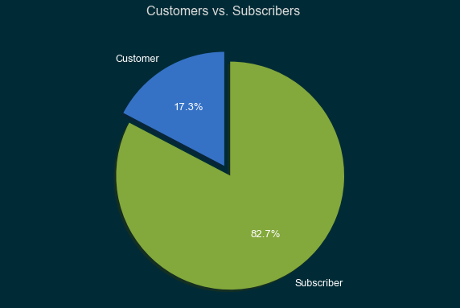

```python
# Customers vs Subscribers Pie Chart
# pie chart
plt.figure(figsize = [10, 6])
#prepare label and design data
labels = ['Customer', 'Subscriber']
size = [customer_prop, subscriber_prop]
explode = (0, 0.1)
# Actual plot call
plt.pie(size, explode=explode, labels = labels, autopct='%1.1f%%', shadow=True, startangle=90, textprops={'color':'white'})
# Polish the plot a bit
plt.suptitle('Customers vs. Subscribers', y=0.98, fontsize=16, fontweight='normal');
plt.axis('equal')
```

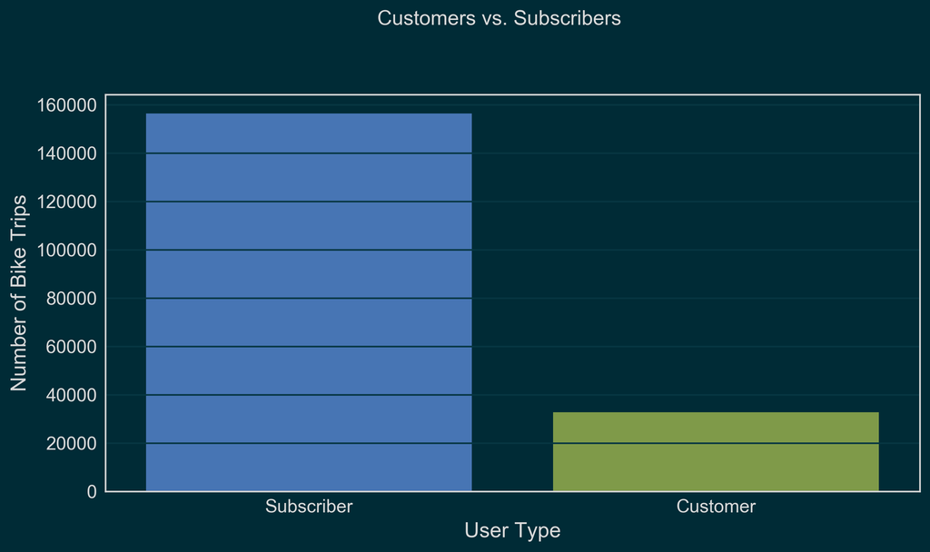

```python
# Customers vs Subscribers Absolute Bar Chart
# bar chart
plt.figure(figsize = [10,5],dpi=300)

ax = sb.countplot(data = df_cleaned, x = "user_type", order = df_cleaned.user_type.value_counts().index);
ax.set_xlabel('User Type');
ax.set_ylabel('Number of Bike Trips');
plt.suptitle('Customers vs. Subscribers', y=1.04, fontsize=14, fontweight='normal');
```

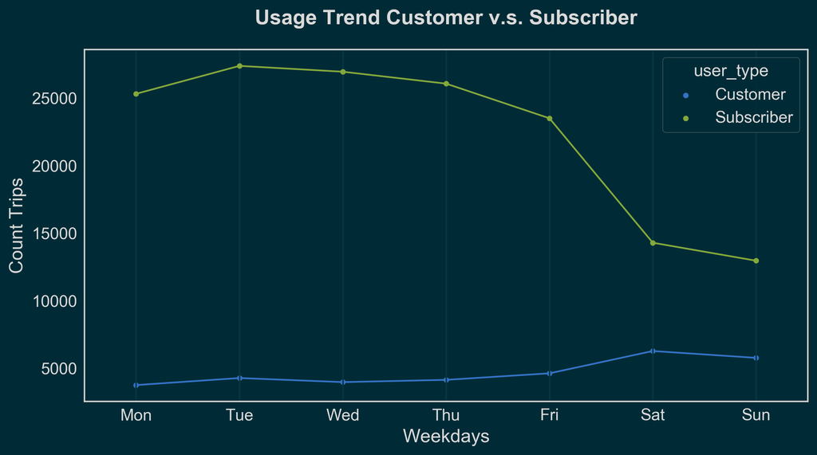

```python
# Customer Usage by Weekday vs. Subscriber Usage by Weekday
# Create fig size
plt.figure(figsize=(10, 5),dpi=300)
# Prepare the data to plot
weekdays = ['Mon', 'Tue', 'Wed', 'Thu', 'Fri', 'Sat', 'Sun']
df_cleaned_usage_weekdays = df_cleaned.groupby(['start_time_weekday', 'user_type']).size().reset_index()
# Actual call for plot the data
ax = sb.pointplot(data=df_cleaned_usage_weekdays, x='start_time_weekday', y=0, hue = 'user_type', scale=.6, order = weekdays);
# Polish the plot
plt.title('Usage Trend Customer v.s. Subscriber', y=1.05, fontsize=16, fontweight='bold')
plt.xlabel('Weekdays')
plt.ylabel('Count Trips');
plt.grid()
```

*Observation:* First, the pie and bar chart show, there is significant higher amount of subscribers then customers.

The point plot shows an interesting differencde between the two groups of user types. They use the system almost in a complete invers way. Customers show a quite low usage of the bike share system during weekdays and a bit more on weekends. Subscribers are the opposite - they show high usage on weekdays and a sharp decline on the weekends for the month of June 2019.

```python
# Customer v.s. Subscriber Usage by duration
df_cleaned.duration_min.describe(percentiles = [.95])
```

```
count    189069.000000
mean         13.542929
std          32.451795
min           1.000000
50%           9.000000
95%          30.000000
max        1432.000000
Name: duration_min, dtype: float64
```

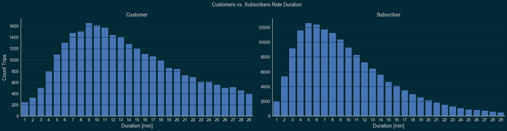

```python
# Customer Usage by Duration vs. Subscriber Usage by Duration
plt.figure(figsize = (15, 10), dpi=300)

# Filter data for outliers
df_cleaned_filtered_30_min_duration = df_cleaned.query('duration_min < 30')
# Actual plot of the histogram
ax = sb.catplot(data=df_cleaned_filtered_30_min_duration, x = 'duration_min', col='user_type', kind='count', sharey = False, color = no_color,height=5,aspect=2);

ax.fig.suptitle('Customers vs. Subscribers Ride Duration', y=1.04, fontsize=14, fontweight='normal');
ax.set_axis_labels('Duration [min]', 'Count Trips')
ax.set_titles('{col_name}')
ax.set_xticklabels(rotation=0);
```

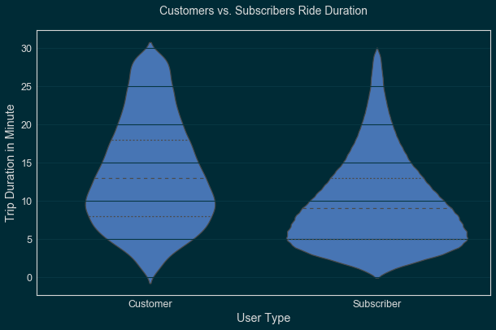

```python
#define title
plt.figure(figsize = [10,6],dpi=300)
# Actul plot call for plotting the violine plot
sb.violinplot(data=df_cleaned_filtered_30_min_duration, x='user_type', y='duration_min', color=no_color, inner='quartile');
# Polish the plot for better readablility
plt.xlabel('User Type');
plt.ylabel('Trip Duration in Minute');
plt.title('Customers vs. Subscribers Ride Duration', y=1.04, fontsize=14, fontweight='normal');
```

### Talk about some of the relationships you observed in this part of the investigation. How did the feature(s) of interest vary with other features in the dataset?

Investigating the user type (customers and subscribers) and plot it relative to other feature like useage time or weekdays showed interesting differences in the behaviors of both groups. Obviously the customers are more kind of type tourists. It'S still a hunch but it gets backed up by mutltiple plots. We can see it when looking at the duration in minutes and we can see it when looking at the weekdays. Both plots suggest and support the hypothesis that subscribers are the commuters while customers are more explorers of the area. Different goals. For more details one can check the section observations per plot.

### Did you observe any interesting relationships between the other features (not the main feature(s) of interest)?

The usage of the bike system and the difference between customer user and subscriber came clear by looking across different plots and reading between the line. The behavior difference has been described extensively above already.

## Multivariate Exploration

#### Multivariate investigation: Average duration across user type and weekdays

Let's explore the variation or differences in the usage during weekdays betweent he two interesting user types.

- What does the mean of a trip duration vary acroos the two user types innrealtion to the weeksday?

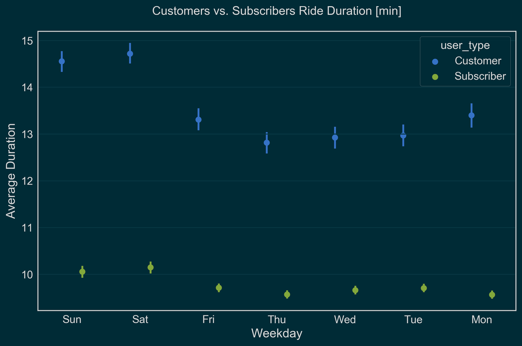

```python
#define Figsize and resolution

plt.figure(figsize = [10,6],dpi=300)

# Actul plot call for plotting the violine plot
sb.pointplot(data=df_cleaned_filtered_30_min_duration, x='start_time_weekday', y='duration_min', hue='user_type', dodge=0.3, linestyles="");

# Polish the plot for better reabability
plt.xlabel('Weekday');
plt.ylabel('Average Duration');
plt.title('Customers vs. Subscribers Ride Duration [min]', y=1.04, fontsize=14, fontweight='normal');
```

*Observation:* First things first, Subscribers ride much shorter/quicker trips compared to customers independent of the weekday. We observe for both types a significant increase of trip duration on Saturdays and Sundays. The subscriber show a much more predictable user behavior. That makes the subscriber for business and sharing system dependency reasons the better consumer overall. This matches with the previous observation in this data set and all the plots above. Finally this alligns with the higher amount of volatility in the average trip duration for customers. One could say, the customers are the bad guys in this game and one could think about making this bike share service a subscriber model only for maximize the profit. If this is the goal.

#### Multivariate investigation: Average hourly usage across user type and weekdays

Let's think about the differences in hourly usage. This is a quite important question every ride share service needs to answer for the reason of "how to distribute the bikes across the city and especially where to place the return stations"

Question: How does the hourly usage look like Weekdays for customers and subscribers?

```python
df_cleaned.head()
```

|  | duration_sec | start_time | end_time | start_station_id | start_station_name | start_station_latitude | start_station_longitude | end_station_id | end_station_name | end_station_latitude | ... | bike_id | user_type | bike_share_for_all_trip | rental_access_method | start_time_weekday | start_time_hour | end_time_hour | start_time_month | start_time_month_num | duration_min |
| --- | --- | --- | --- | --- | --- | --- | --- | --- | --- | --- | --- | --- | --- | --- | --- | --- | --- | --- | --- | --- | --- |
| 0 | 81695 | 2019-06-30 18:16:09.773 | 2019-07-01 16:57:45.592 | 109.0 | 17th St at Valencia St | 37.763316 | -122.421904 | 56.0 | Koshland Park | 37.773414 | ... | 1502 | Subscriber | No | NaN | Sun | 18 | 16 | June | 6 | 1361 |
| 1 | 74260 | 2019-06-30 18:09:55.830 | 2019-07-01 14:47:36.681 | 50.0 | 2nd St at Townsend St | 37.780526 | -122.390288 | 101.0 | 15th St at Potrero Ave | 37.767079 | ... | 2526 | Customer | No | NaN | Sun | 18 | 14 | June | 6 | 1237 |
| 2 | 59603 | 2019-06-30 15:40:31.038 | 2019-07-01 08:13:54.349 | 23.0 | The Embarcadero at Steuart St | 37.791464 | -122.391034 | 30.0 | San Francisco Caltrain (Townsend St at 4th St) | 37.776598 | ... | 2427 | Subscriber | No | NaN | Sun | 15 | 8 | June | 6 | 993 |
| 3 | 67932 | 2019-06-30 12:49:47.781 | 2019-07-01 07:42:00.543 | 169.0 | Bushrod Park | 37.846516 | -122.265304 | 248.0 | Telegraph Ave at Ashby Ave | 37.855956 | ... | 1261 | Customer | No | NaN | Sun | 12 | 7 | June | 6 | 1132 |
| 4 | 48894 | 2019-06-30 17:21:00.055 | 2019-07-01 06:55:54.996 | 15.0 | San Francisco Ferry Building (Harry Bridges Pl... | 37.795392 | -122.394203 | 30.0 | San Francisco Caltrain (Townsend St at 4th St) | 37.776598 | ... | 1070 | Customer | No | NaN | Sun | 17 | 6 | June | 6 | 814 |

5 rows × 21 columns

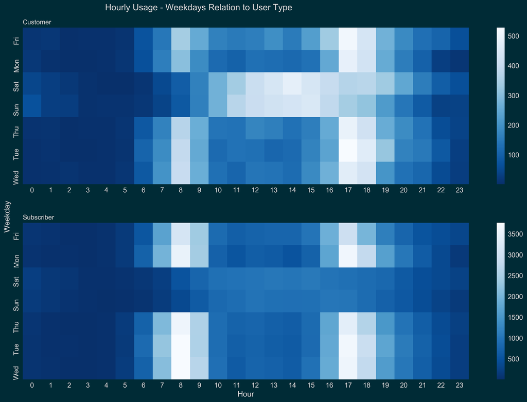

```python
# Create General Figure size for better visualization
fig, ax = plt.subplots(2, 1, figsize = (15, 10), dpi=300)
fig.suptitle('Hourly Usage - Weekdays Relation to User Type',y=1.02, horizontalalignment='right')

# Create first subplot for the customer relation to hour and weekday
plt.subplot(2, 1, 1)

#create customer data only
customer_data = df_cleaned_filtered_30_min_duration.query('user_type == "Customer"')
customer_counts = customer_data.groupby(['start_time_weekday', 'start_time_hour']).size()
customer_counts = customer_counts.reset_index(name='count')
customer_counts = customer_counts.pivot(index='start_time_weekday', columns='start_time_hour', values='count')
# Call for the heat map plot for cutomer
sb.heatmap(customer_counts, cmap='Blues_r');
# polish the plot for better readability
plt.title('Customer', loc='left',fontsize = 12);
# Remove labels
plt.ylabel('')
plt.xlabel('')

# Doin principle the same for the Subscriber as we have done above
plt.subplot(2, 1, 2)
# Prepare subscriber data
subscribers_data = df_cleaned_filtered_30_min_duration.query('user_type == "Subscriber"')
subscribers_counts = subscribers_data.groupby(['start_time_weekday', 'start_time_hour']).size()
subscribers_counts = subscribers_counts.reset_index(name='count')
subscribers_counts = subscribers_counts.pivot(index='start_time_weekday', columns='start_time_hour', values='count')
# Call heatmap plot
sb.heatmap(subscribers_counts, cmap='Blues_r');
#Polish
plt.title('Subscriber', loc='left',fontsize = 12);
plt.xlabel('Hour',y=1.04, fontsize=14, fontweight='normal');
plt.ylabel('Weekday', y=1.04, fontsize=14, fontweight='normal');
# Auto allign
fig.tight_layout()
```

Overall this plot is the best plot for getting a fast and clear insight on this two groups in relation to the most important features like weekdays and hours. I would make this plot the most important plot for my sharing system evaluation and for decision making.

### Talk about some of the relationships you observed in this part of the investigation. Were there features that strengthened each other in terms of looking at your feature(s) of interest?

The multivariate plots confirm and strengthen somehow the observation we made in some of the univariate and bivariate plots beforehand. Especially the heatmap plot provides a quick and intense insight on the user profile which couldn't be achieved by using univariate of bivariate plots before. We can see again that the way shorter durations of usage for subscribers corresponds to their high concentration on rush hours Monday through Friday.

PLotting weeksdays across hours and amount of bikerides (as counts via color code) really strengthened the assumption from previous plots.

### Were there any interesting or surprising interactions between features?

For there were interesting insights in terms of seeing a that huge differenc between the two subscriber groups. Overall all features and there colleration are just logical to me and so I can't say that I had any suprises observed during my investigations.